# Extensão e Sociologia Rural

Políticas Públicas para o Meio Rural  
Agendas, Programas e Institucionalização

Luiz Diego Vidal Santos

## Visão Geral

### Tópicos Principais

- 1 Conceitos Fundamentais (Rural e Questão Agrária)
- 2 Contextualização Histórica
- 3 Estatuto da Terra e Modernização
- 4 Lei da Agricultura Familiar e PNATER
- 5 PRONAF e Outros Programas

**Objetivo Central**

Compreender as políticas públicas voltadas ao meio rural brasileiro, desde o Estatuto da Terra até a PNATER e os programas de apoio à agricultura familiar.

## CONCEITOS FUNDAMENTAIS

Antes de abordar as políticas públicas, é fundamental definir conceitos-chave:

**Meio Rural (Kageyama, 2008):**

1. Espaço com maior presença de **áreas verdes ou naturais**
2. Maiores **distâncias** entre unidades residenciais e comerciais
3. Maior **dispersão** e menor densidade populacional
4. Maior presença de atividades dependentes de **recursos naturais**
5. Representações **culturais e simbólicas** atreladas à ruralidade

## QUESTÃO AGRÁRIA vs. QUESTÃO AGRÍCOLA

**Questão Agrária** (Graziano da Silva, 1980; Veiga, 1991; Navarro, 2011):

Compreensão das **relações sociais** do meio rural - relações de trabalho, renda, direitos políticos e de gênero.

O campo enquanto **ambiente social**.

**Questão Agrícola:**

O campo enquanto **artefato econômico** - produção, consumo, forças produtivas e tecnologias emergentes.

## BREVE CONTEXTUALIZAÇÃO HISTÓRICA

A institucionalização da estrutura agrária no Brasil foi marcada por políticas voltadas à consolidação de **poucos grupos oligárquicos**:

- **Sesmarias** → Lei de Terras de 1850
- Consolidação de **grandes latifúndios**
- Pouco feito ao pequeno produtor

A partir das **lutas dos movimentos sociais**, surgem discussões sobre possíveis ações do poder público.

## ESTATUTO DA TERRA (Lei 4.504/64)

[figure not shown]

Colheitadeira em operação - símbolo da mecanização agrícola viabilizada pelo crédito rural (Fortepan / Urbán Tamás, CC-BY-SA 3.0)

**Objetivos:**

- Regulamentar o **uso social** dos imóveis rurais
- *“Terra para quem vive, trabalha e mora”*
- Criar princípios da **reforma agrária**
- Incentivar o desenvolvimento de políticas de **crédito**

**Desdobramentos:**

- Sistema Brasileiro de Crédito Rural (década de 1960)
- **PROAGRO** - Lei 5.969/73: seguro e financiamento agrícola (Alves, 2012)

## MODERNIZAÇÃO: DEBATE

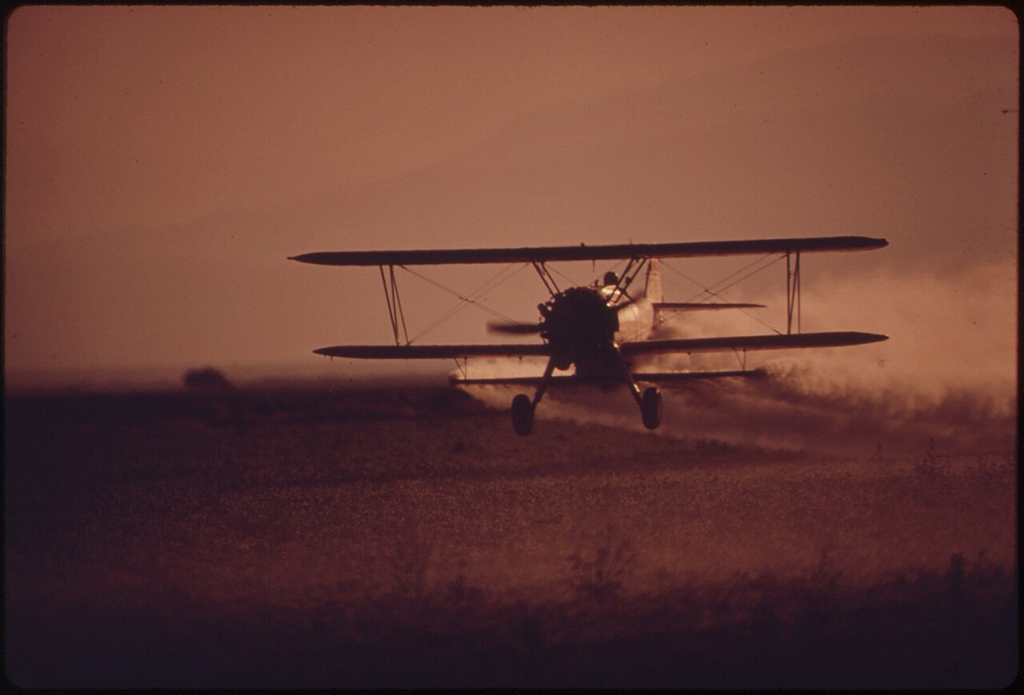

Pulverização aérea de lavoura - pacote tecnológico da Revolução Verde (NARA / Charles O’Rear, domínio público)

Há muitos debates sobre se a modernização do campo:

- Resolve de fato as **questões agrárias**, ou
- Apenas cria uma **reserva de mão de obra** no campo

A concentração de políticas na **questão agrícola** (décadas de 1970-2000) aprofundou as **diferenças sociais e econômicas** no campo.

Este aprofundamento, somado às articulações de **movimentos sociais**, levou à necessidade de políticas focadas na **pluralidade do campo**.

## LEI DA AGRICULTURA FAMILIAR (11.326/06)

**Requisitos para titulação:**

- Gestão realizada por indivíduos com **laços familiares**
- Maior parte do trabalho fornecida pela **família**
- Renda mínima originada da **propriedade rural**
- Propriedade dos meios de produção pertence à **família**
- Máximo de **quatro módulos fiscais**

**Ampliação:** silvicultura, extrativismo, pesca artesanal, povos originários.

## EXTENSÃO RURAL - EMBRATER

A assistência técnica e extensão rural tomou força com a **Lei 6.126/74**:

- Estatizou o sistema brasileiro de extensão rural
- Instituiu a **EMBRATER** (Peixoto, 2008)

Porém, a ATER focada majoritariamente na questão agrícola conduziu o Brasil a aprofundar as diferenças no campo.

## PNATER E PRONATER

**Lei 12.188/2010** - Política Nacional de ATER:

Voltada para a **melhoria das condições de vida** da população rural.

**PRONATER** - Quatro subprogramas:

1. Capacitação de **agentes de ATER**
2. Capacitação de **agricultores familiares**
3. Programas **estaduais de ATER**
4. ATER **Setorial**

*(MDA, 2013)*

## PRINCÍPIOS DA PNATER

- **Inclusão social** - superar discriminação e exclusão
- **Transição para agricultura ecológica** - práticas agroecológicas
- **Articulação ATER-pesquisa-ensino** - integração institucional
- **Reconhecimento de diversidades** - povos originários, quilombolas, pescadores
- **Geração de ocupação e renda** - diversificação produtiva
- **Atuação em redes** - cooperação entre instituições

## PRONAF

**Programa Nacional de Fortalecimento da Agricultura Familiar**

Criado por resolução do BACEN e regulamentado pelo Decreto Lei 1.946/96.

**Objetivo:** Melhorar a qualidade de vida do produtor rural por meio de subvenções e apoio financeiro/técnico.

**Subprogramas:**

- PRONAF Mulher, Jovem, Mais Alimentos
- PRONAF ABC+, Agroecologia
- Grupo B, Cotas Partes

## OUTROS PROGRAMAS

As políticas públicas podem ser segmentadas por natureza e objetivo:

| Natureza | Exemplos |
| --- | --- |
| **Políticas sociais** | Luz para Todos, Programa Nacional de Habitação Rural |
| **Segurança alimentar** | PAA, PNAE |
| **Políticas agrárias** | Seguro Rural, Crédito Fundiário |
| **Políticas agrícolas** | PRONAF, PNATER |

## CONCLUSÃO

A trajetória histórica das políticas agrárias e agrícolas demonstra uma **evolução significativa** na abordagem e reconhecimento das particularidades do setor.

É imperativo que o Estado, em parceria com a **sociedade civil** e os **movimentos sociais**, continue aprimorando políticas que atendam às demandas do campo, garantindo:

- Segurança alimentar
- Proteção ambiental
- Desenvolvimento sustentável

## REFERÊNCIAS

- Alves, P. D. Políticas Agrícolas para agricultura familiar (2012)
- Brasil. Lei 4.504/64 - Estatuto da Terra (1964)
- Brasil. Lei 5.969/73 - PROAGRO (1973)
- Brasil. Lei 6.126/74 - EMBRATER (1974)
- Brasil. Lei 11.326/06 - Agricultura Familiar (2006)
- Brasil. Lei 12.188/2010 - PNATER/PRONATER (2010)
- Kageyama, A. A. Desenvolvimento rural (2008)
- Peixoto et al. Extensão rural no Brasil (2008)
- Schneider, S.; Grisa, C. Três Gerações de Políticas Públicas (2015)

Obrigado!

Luiz Diego Vidal Santos

Universidade Federal de Sergipe (UFS)